# main

2024-12-05

## Загрузка данных

```r
data_path <- 'data/beta_1/'
load_file <- function(file) {
  temp_dt <- read.csv(str_c(data_path, file))
  temp_dt$id <- temp_dt[temp_dt$sender == 'Анкета', ]$id
  return(temp_dt)
}
dt <- do.call('rbind',
              data_path %>%
                list.files() %>%
                lapply(load_file)
)
dt <- dt %>%
        filter(sender == "Ответ *код") %>%
        select(id, interval, condition_direction, condition_image, order, prob_i, response,duration)
```

# Анализ самоотчётов

### Графики

```r
graph_dt <- dt

graph_dt$condition_direction <- str_replace(graph_dt$condition_direction, 'counterclockwise', 'появ. прот. час.')
graph_dt$condition_direction <- str_replace(graph_dt$condition_direction, 'clockwise', 'появ. по час.')

graph_dt$response <- str_replace(graph_dt$response, 'counterclockwise', 'каж. прот. час.')
graph_dt$response <- str_replace(graph_dt$response, 'clockwise', 'каж по. час.')
graph_dt$response <- str_replace(graph_dt$response, 'down', 'нет каж. движ.')
graph_dt$order <- graph_dt$order %>% as.factor()
```

```
## 'condition_image'. You can override using the `.groups` argument.
```

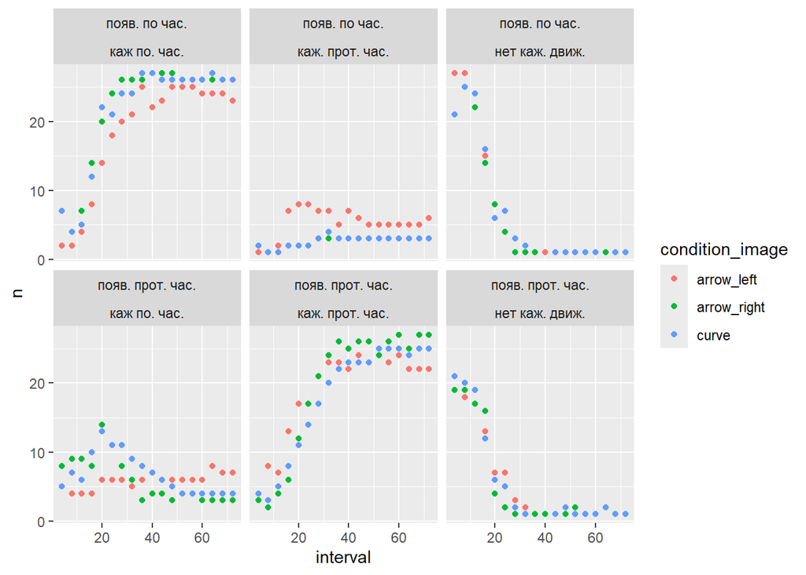

```r
graph_dt %>%
  filter(order == 'asc') %>%
  group_by(interval, condition_direction, condition_image, response) %>%
  summarise(n = n()) %>%
  ggplot(aes(y = n, x = interval, color = condition_image))+
  geom_point()+
  facet_wrap(~ condition_direction + response)
```

```r
ggsave("график1_частота_ответов_при_разных_интервалах_и_стимульных_материалах_возрастание.png")
```

```
## 'condition_image'. You can override using the `.groups` argument.
```

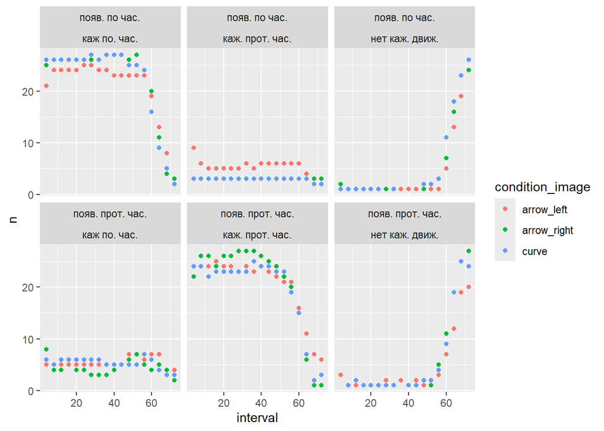

```r
graph_dt %>%
  filter(order == 'desc') %>%
  group_by(interval, condition_direction, condition_image, response) %>%
  summarise(n = n()) %>%
  ggplot(aes(y = n, x = interval, color = condition_image))+
  geom_point()+
  facet_wrap(~ condition_direction + response)
```

```r
ggsave("график1_частота_ответов_при_разных_интервалах_и_стимульных_материалах_убывание.png")
```

График по возрастанию без кривых

```
## 'condition_image'. You can override using the `.groups` argument.
```

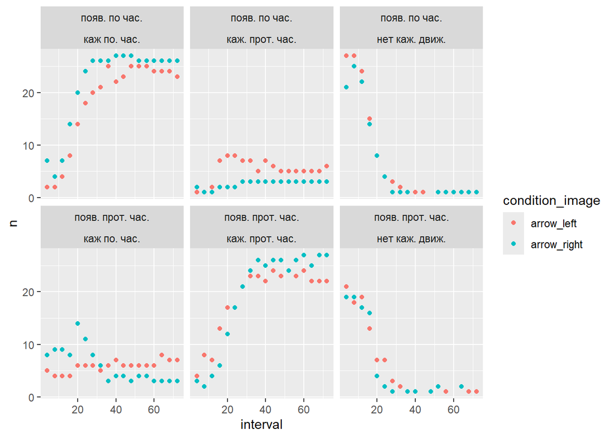

```r
graph_dt %>%
  filter(order == 'asc' & condition_image != 'curve') %>%
  group_by(interval, condition_direction, condition_image, response) %>%
  summarise(n = n()) %>%
  ggplot(aes(y = n, x = interval, color = condition_image))+
  geom_point()+
  facet_wrap(~ condition_direction + response)
```

```r
ggsave("график1_частота_ответов_при_разных_интервалах_и_стимульных_материалах_возрастание_без_кривых.png")
```

**Зелёное** - стрелки по часовой

**Красное** - стрелки против часовой

**Синие -** кривые

Реже всего отвечали, что кажется движение по часовой (когда стрелки предъявлились по часовой) при стрелках повёрнутых в лево, а чаще в право.

Явно есть вляние порядка предъявления - в зависимости от порядка люди говорят, что нет движения, а потом начинают говорить, что оно есть. Вне зависимости от стороны.

В случае, когда появление было по часовой, а люди отвечали, что оно против часовой (происходило достаточно редко) было для стрелок направленных влево. Скорее всего моторный конфликт.

На появление против часовой эти закономерности не направляются. Частота кажущегося движения по часовой, при появлении против часовой существенно больше, чем в обратном случае.

*Возможно* - у добровольцев есть ожидания, что движение должно быть по часовой стрелки - и это ожидание создаёт дополнительную дисперсию в данных. Действие этого ожидания может быть намного больше, чем действии стрелок в качестве стимульного материала.

```
## can override using the `.groups` argument.
```

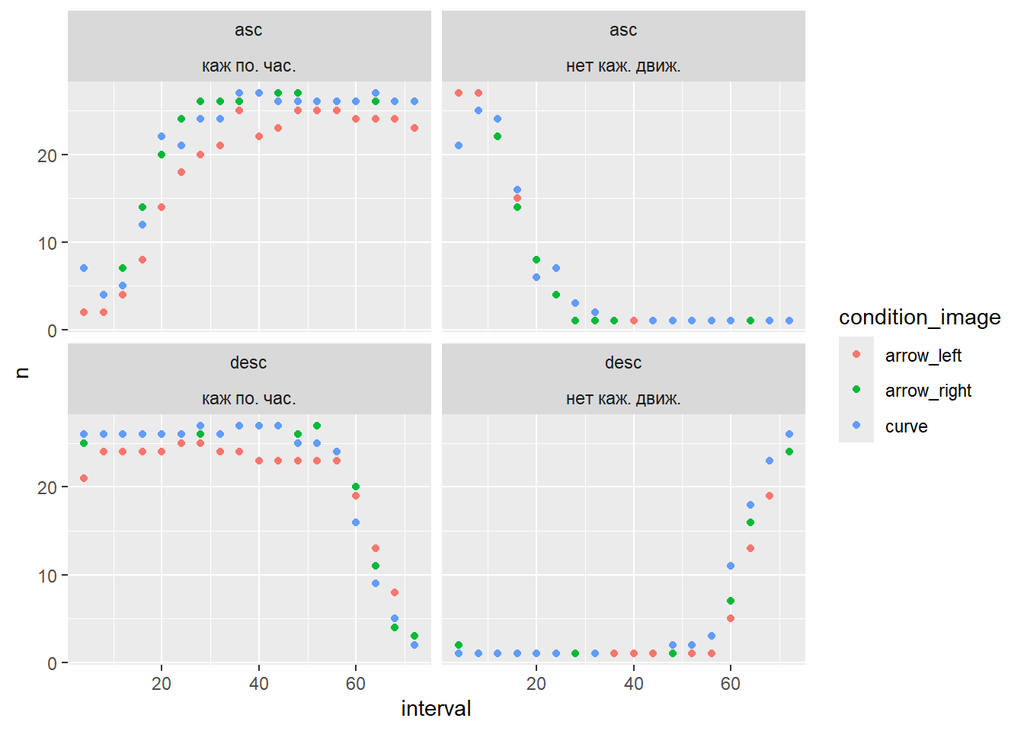

```r
graph_dt %>%
  filter(condition_direction == 'появ. по час.' &
         response != 'каж. прот. час.') %>%
  group_by(interval, order, condition_image, response) %>%
  summarise(n = n()) %>%
  ggplot(aes(y = n, x = interval, color = condition_image))+
  geom_point()+
  facet_wrap(~ order + response)
```

```r
graph_dt %>%
  filter(condition_direction == 'появ. по час.' &
         response != 'каж. прот. час.') %>%
  write.csv('graph_dt.csv')
```

## Сравнение распределений

В связи с тем, что проб на каждое условие для человек мало - было принято решение попробовать сравнить общие распределения признаков.

Для появ. по час., без интерферирующих ответов каж. прот. час.

Также на графиках видно существенное при условиях предъявления (по возрастанию / по убыванию).

```r
graph_dt %>%
  filter(condition_direction == 'появ. по час.' &
         response != 'каж. прот. час.' &
         order == 'asc') %>%
  mutate(resp_num = as.numeric(response == 'каж по. час.')) %>%
  group_by(interval, condition_image) %>%
  summarise(freq = sum(resp_num))-> dt_ad
write.csv(dt_ad, 'dt_ad.csv')
```

### Тест Андерсона-Дарлинга

Сранвение двух распределений - распределения ответов с одним типом стимула и распределение ответа с другим типом стимула.

```r
ad_test <- ad.test(filter(dt_ad, condition_image == 'arrow_right')$freq,
                   filter(dt_ad, condition_image == 'arrow_left')$freq)
print(ad_test)
```

```
##
##
##  Anderson-Darling k-sample test.
##
## Number of samples:  2
## Sample sizes:  18, 18
## Number of ties: 22
##
## Mean of  Anderson-Darling  Criterion: 1
## Standard deviation of  Anderson-Darling  Criterion: 0.7238
##
## T.AD = ( Anderson-Darling  Criterion - mean)/sigma
##
## Null Hypothesis: All samples come from a common population.
##
##                AD   T.AD  asympt. P-value
## version 1: 4.1617 4.3682        0.0061167
## version 2: 6.5600 7.6875        0.0003614
```

Такое же сравнение, для кривых (стрелки вправо / кривые)

```r
ad_test <- ad.test(filter(dt_ad, condition_image == 'arrow_right')$freq,
                   filter(dt_ad, condition_image == 'curve')$freq)
print(ad_test)
```

```
##
##
##  Anderson-Darling k-sample test.
##
## Number of samples:  2
## Sample sizes:  18, 18
## Number of ties: 25
##
## Mean of  Anderson-Darling  Criterion: 1
## Standard deviation of  Anderson-Darling  Criterion: 0.7238
##
## T.AD = ( Anderson-Darling  Criterion - mean)/sigma
##
## Null Hypothesis: All samples come from a common population.
##
##                 AD    T.AD  asympt. P-value
## version 1: 0.06174 -1.2963          1.00000
## version 2: 0.13500 -1.1956          0.99999
```

Различий нет - т.е. распределение человек, которые видели движение при кривых и при стрелках вправо - значимо не отличается

```r
ad_test <- ad.test(filter(dt_ad, condition_image == 'arrow_left')$freq,
                   filter(dt_ad, condition_image == 'curve')$freq)
print(ad_test)
```

```
##
##
##  Anderson-Darling k-sample test.
##
## Number of samples:  2
## Sample sizes:  18, 18
## Number of ties: 20
##
## Mean of  Anderson-Darling  Criterion: 1
## Standard deviation of  Anderson-Darling  Criterion: 0.7238
##
## T.AD = ( Anderson-Darling  Criterion - mean)/sigma
##
## Null Hypothesis: All samples come from a common population.
##
##                AD   T.AD  asympt. P-value
## version 1: 3.2751 3.1433        0.0173900
## version 2: 4.5100 4.8495        0.0040642
```

Таким образом, распределение ответов участников, где есть стрелки вправо отличается от того, где стрелки влево. При этом стрелки влево отличаются от кривых, а стрелки вправо не отличаются от кривых.

Как будто бы стрелки влево больше мешают, чем помогают стрелки вправо относительно просто кривых.

### График с линией тренда и 95% доверительным интервалом

Для проб, где элементы предъявлялись по часовой стрелки подсчитывается частота людей, которые дали ответ, что им кажется движение по часовой. Были изображены линии тренда (не линейная регрессия) и 95% интервалы для этих линий. Были взяты два условия - по возрастанию и по убыванию.

Для следующего графика были взяты два условия стрелки вправо и стрелки влево (максимально контрастные условия)

```
## can override using the `.groups` argument.
```

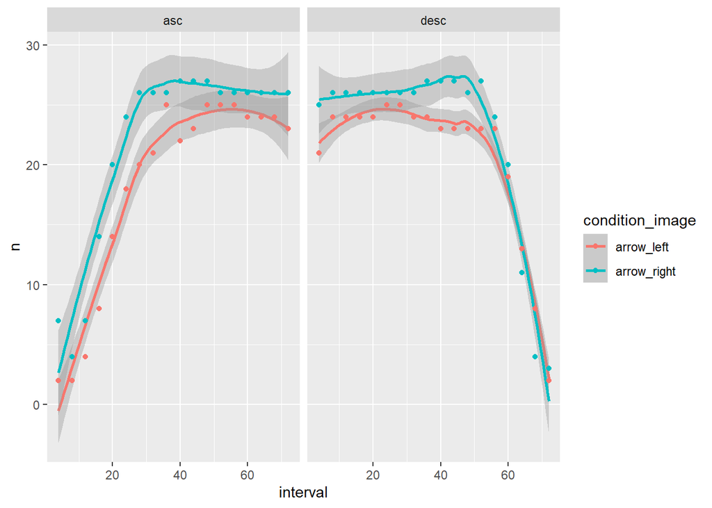

```r
graph_dt %>%
  filter(condition_direction == 'появ. по час.' &
         response == 'каж по. час.' &
         condition_image != 'curve') %>%
  group_by(interval, order, condition_image, response) %>%
  summarise(n = n()) %>%
  ggplot(aes(y = n, x = interval, color = condition_image))+
  geom_smooth(method = "loess", se = TRUE, level = 0.95) +  # 95% CI
  geom_point()+
  facet_wrap(~ order)
```

```r
ggsave("график частоты ответов вместе с доверительными интервалами (left vs right).png")
```

В какой то момент доверительные интервалы начинают пересекаться. Т.е. можно сказать, что стимульный материал различается в основном на интервала с 4 до 32. Визуально видно, как график со стрелками влево как бы сдвигается дальше (**т.е. начинает проявляться на более поздних интервалах)**. Причём график для нисходящего предъявления отличается.

График с условиями стрелка вправо и кривые

```
## can override using the `.groups` argument.
```

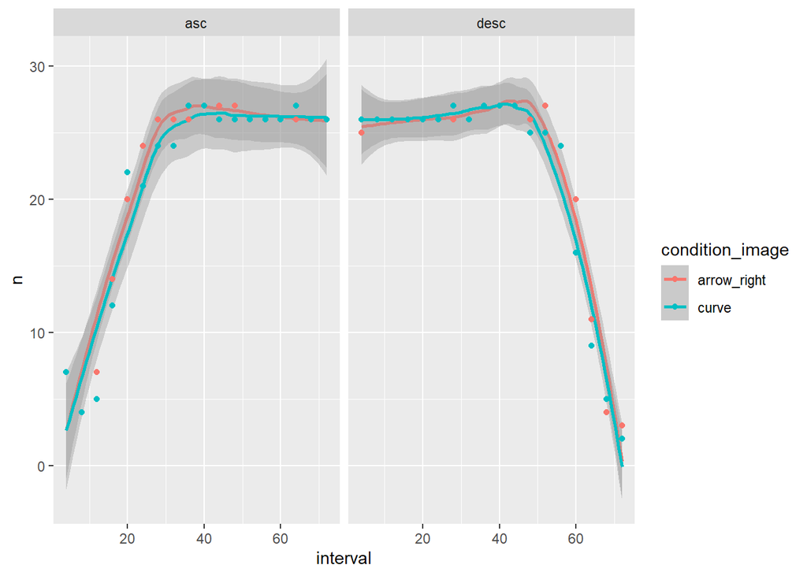

```r
graph_dt %>%
  filter(condition_direction == 'появ. по час.' &
         response == 'каж по. час.' &
         condition_image != 'arrow_left') %>%
  group_by(interval, order, condition_image, response) %>%
  summarise(n = n()) %>%
  ggplot(aes(y = n, x = interval, color = condition_image))+
  geom_smooth(method = "loess", se = TRUE, level = 0.95) +  # 95% CI
  geom_point()+
  facet_wrap(~ order)
```

```r
ggsave("график частоты ответов вместе с доверительными интервалами (curve vs right).png")
```

Видно, что доверительные интервалы полностью пересекаются. Таким образом можно предположить, что стрелка вправо не столько увеличивает количество ответов, сколько стрелка влево их уменьшает.

Т.е. стрелка влево сдвигает эффект кажущегося движения на более крупные интервалы предъявления стимула.

### График для появления против часовой

```
## can override using the `.groups` argument.
```

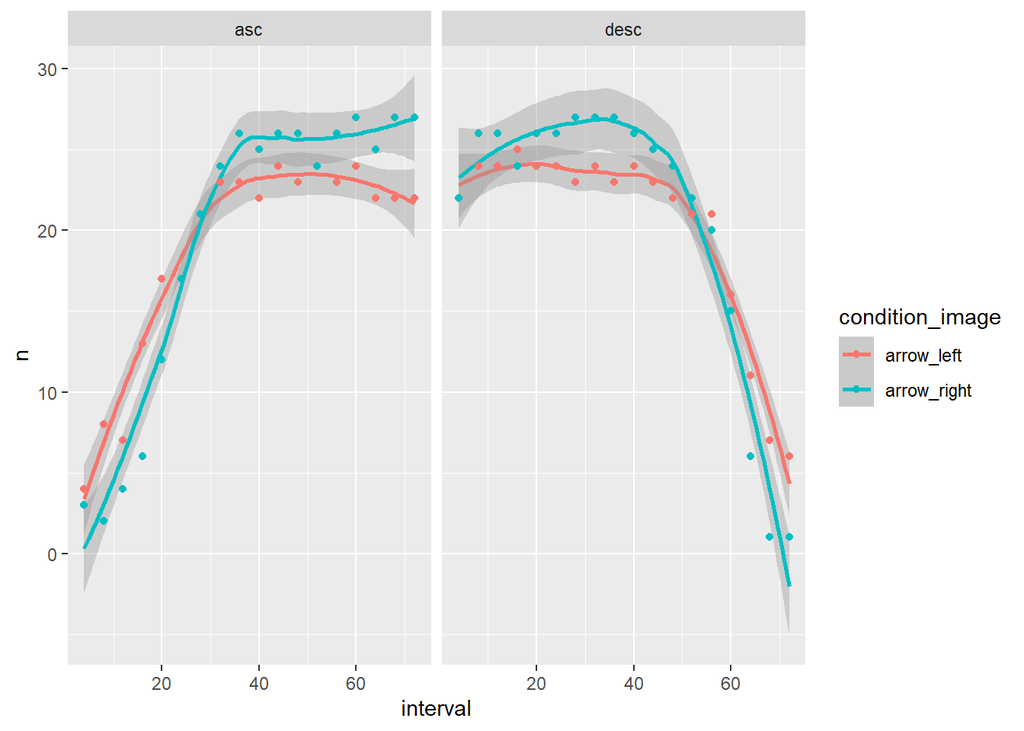

```r
graph_dt %>%
  filter(condition_direction != 'появ. по час.' &
         response == 'каж. прот. час.' &
         condition_image != 'curve') %>%
  group_by(interval, order, condition_image, response) %>%
  summarise(n = n()) %>%
  ggplot(aes(y = n, x = interval, color = condition_image))+
  geom_smooth(method = "loess", se = TRUE, level = 0.95) +  # 95% CI
  geom_point()+
  facet_wrap(~ order)
```

```r
ggsave("график частоты ответов вместе с доверительными интервалами - против (left vs right).png")
```

### Сравнение по критериям

```r
chi_test <- function(i) {
  dt %>%
    filter(condition_direction == 'clockwise' &
           order == 'asc' &
           response == 'clockwise' &
           condition_image != 'curve' &
           interval == i) %>%
    mutate(condition = condition_image) %>%
    select(condition) %>%
    table() %>%
    chisq.test() %>%
    print()
}
```

```r
chi_test(4)
```

```
##
##  Chi-squared test for given probabilities
##
## data:  .
## X-squared = 2.7778, df = 1, p-value = 0.09558
```

```r
chi_test(8)
```

```
##
##  Chi-squared test for given probabilities
##
## data:  .
## X-squared = 0.66667, df = 1, p-value = 0.4142
```

```r
chi_test(12)
```

```
##
##  Chi-squared test for given probabilities
##
## data:  .
## X-squared = 0.81818, df = 1, p-value = 0.3657
```

```r
chi_test(16)
```

```
##
##  Chi-squared test for given probabilities
##
## data:  .
## X-squared = 1.6364, df = 1, p-value = 0.2008
```

```r
chi_test(20)
```

```
##
##  Chi-squared test for given probabilities
##
## data:  .
## X-squared = 1.0588, df = 1, p-value = 0.3035
```

```r
chi_test(24)
```

```
##
##  Chi-squared test for given probabilities
##
## data:  .
## X-squared = 0.85714, df = 1, p-value = 0.3545
```

```r
chi_test(28)
```

```
##
##  Chi-squared test for given probabilities
##
## data:  .
## X-squared = 0.78261, df = 1, p-value = 0.3763
```

```r
chi_test(32)
```

```
##
##  Chi-squared test for given probabilities
##
## data:  .
## X-squared = 0.53191, df = 1, p-value = 0.4658
```

Хи-квадрат похоже на таких маленьких частотах не улавливает

# Анализ времени ответа

### Форматирование переменных

```r
dt$condition_direction <- dt$condition_direction %>% as.factor()
dt$condition_image <- dt$condition_image %>% as.factor()
dt$order <- dt$order %>% as.factor()
dt$id <- dt$id %>% as.factor()
#dt$interval <- dt$interval %>% as.factor()
```

### Отсев

```r
min <- mean(dt$duration) - (3*sd(dt$duration))
max <- mean(dt$duration) + (3*sd(dt$duration))

dt_rt <- dt %>% filter(duration > 0 & duration < max)


print('Отсев (проб)')
```

```
## [1] "Отсев (проб)"
```

```r
print(dt %>% nrow() - dt_rt %>% nrow())
```

```
## [1] 26
```

### Описательные статистики

Формирование свободной таблице по всем условиям

```r
dt_rt %>%
  group_by(condition_direction, condition_image, response, order) %>%
  summarise(Mi = median(duration), iqr=IQR(duration)) -> dt_rt_descrip
```

```
## 'response'. You can override using the `.groups` argument.
```

```r
dt_rt_descrip
```

```
## # A tibble: 36 × 6
## # Groups:   condition_direction, condition_image, response [18]
##    condition_direction condition_image response         order    Mi   iqr
##    <fct>               <fct>           <chr>            <fct> <dbl> <dbl>
##  1 clockwise           arrow_left      clockwise        asc    450.  526.
##  2 clockwise           arrow_left      clockwise        desc   353.  349.
##  3 clockwise           arrow_left      counterclockwise asc    380.  674.
##  4 clockwise           arrow_left      counterclockwise desc   352.  434.
##  5 clockwise           arrow_left      down             asc    676.  582.
##  6 clockwise           arrow_left      down             desc   687.  607.
##  7 clockwise           arrow_right     clockwise        asc    351.  384.
##  8 clockwise           arrow_right     clockwise        desc   384.  288.
##  9 clockwise           arrow_right     counterclockwise asc    391.  407.
## 10 clockwise           arrow_right     counterclockwise desc   493.  511.
## # ℹ 26 more rows
```

```r
dt_rt_descrip %>% write.csv('dt_rt_descrip.csv')
```

Свободная таблица по направлению появления элементов

```r
dt_rt %>%
  group_by(condition_direction) %>%
  summarise(Mi = median(duration), iqr=IQR(duration))
```

```
## # A tibble: 2 × 3
##   condition_direction    Mi   iqr
##   <fct>               <dbl> <dbl>
## 1 clockwise            430.  440.
## 2 counterclockwise     546.  644.
```

Свободная таблица по ответу добровольца

```r
dt_rt %>%
  group_by(response) %>%
  summarise(Mi = median(duration), iqr=IQR(duration))
```

```
## # A tibble: 3 × 3
##   response            Mi   iqr
##   <chr>            <dbl> <dbl>
## 1 clockwise         396.  416.
## 2 counterclockwise  477.  543.
## 3 down              760.  689.
```

Сводная таблица по порядку предъявления

```r
dt_rt %>%
  group_by(order) %>%
  summarise(Mi = median(duration), iqr=IQR(duration))
```

```
## # A tibble: 2 × 3
##   order    Mi   iqr
##   <fct> <dbl> <dbl>
## 1 asc    511.  606.
## 2 desc   457.  494.
```

Сводная таблица по типу стимула

```r
dt_rt %>%
  group_by(condition_image) %>%
  summarise(Mi = median(duration), iqr=IQR(duration))
```

```
## # A tibble: 3 × 3
##   condition_image    Mi   iqr
##   <fct>           <dbl> <dbl>
## 1 arrow_left       479.  558.
## 2 arrow_right      494.  557.
## 3 curve            480.  556.
```

### Смешанная модель - время реакции

Проверка нормальности распределения времени

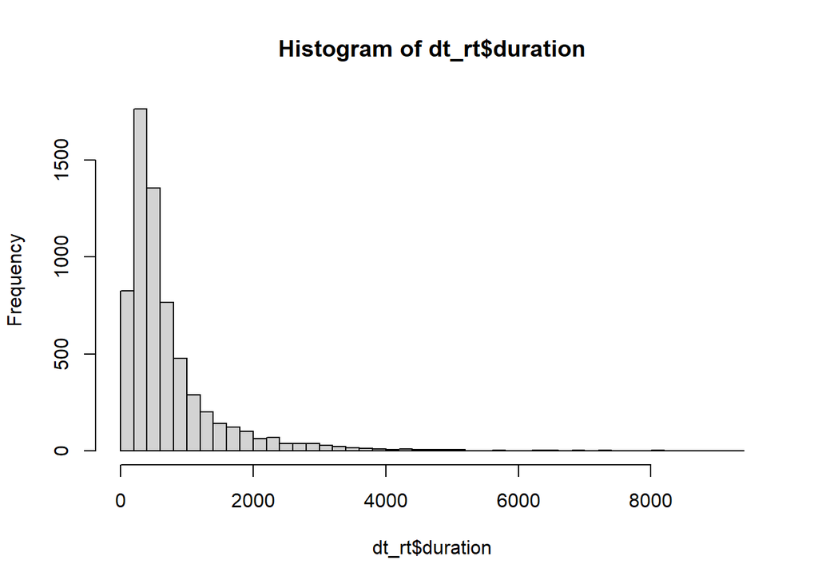

```r
hist(dt_rt$duration, breaks=50)
```

Совсем не нормальное

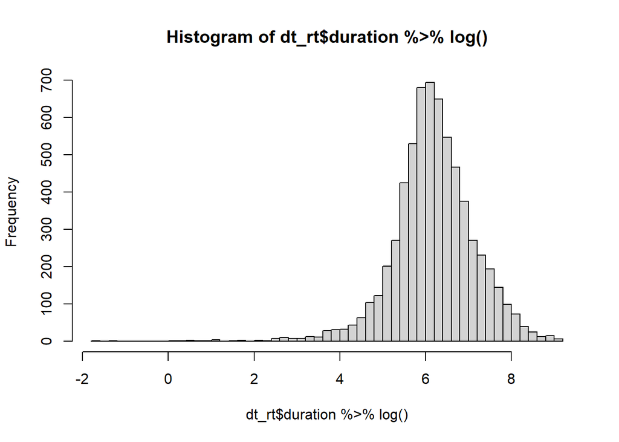

```r
hist(dt_rt$duration %>% log(), breaks=50)
```

Если логарифмировать становится больше похоже на нормальное.

Попытка логорифмировать

```r
dt_rt$log_duration <- log(dt_rt$duration)
ks.test(dt_rt$log_duration, y = "rnorm")
```

```
##
##  Asymptotic one-sample Kolmogorov-Smirnov test
##
## data:  dt_rt$log_duration
## D = 4.6483, p-value < 2.2e-16
## alternative hypothesis: two-sided
```

Логорифмирование не помогает

стоит попрбовать гамма распределение

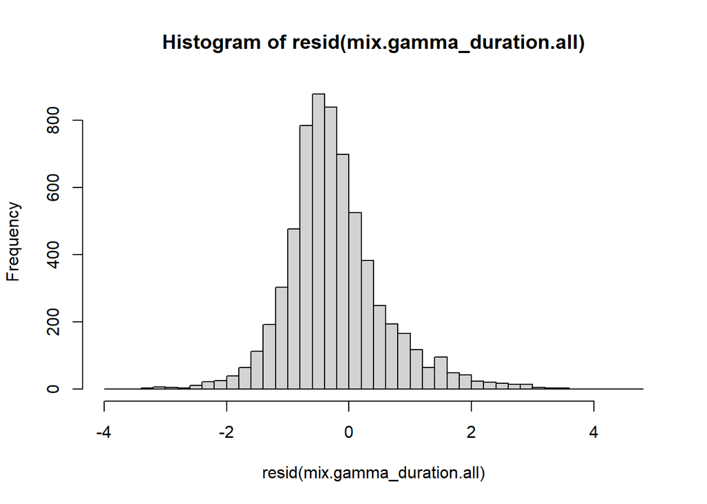

```r
mix.gamma_duration.all <- glmer(
  duration ~ condition_direction*condition_image+order + (1|id),
  family = Gamma,
  data = dt_rt )
hist(resid(mix.gamma_duration.all), breaks=50)
```

```r
ks.test(resid(mix.gamma_duration.all), y = "pnorm")
```

```
##
##  Asymptotic one-sample Kolmogorov-Smirnov test
##
## data:  resid(mix.gamma_duration.all)
## D = 0.19512, p-value < 2.2e-16
## alternative hypothesis: two-sided
```

Визуально - ближе к нормальному чем во всех остальных вариантах

модель где только направления движения + порядок

```r
mix.gamma_duration.cond_order <- glmer(
  duration ~ condition_direction+order + (1|id),
  family = Gamma,
  data = dt_rt )
```

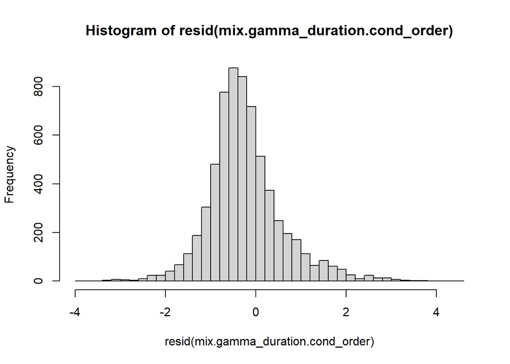

```r
hist(resid(mix.gamma_duration.cond_order), breaks=50)
```

```r
ks.test(resid(mix.gamma_duration.cond_order), y = "pnorm")
```

```
##
##  Asymptotic one-sample Kolmogorov-Smirnov test
##
## data:  resid(mix.gamma_duration.cond_order)
## D = 0.19654, p-value < 2.2e-16
## alternative hypothesis: two-sided
```

Остатки не распределены нормально, модель нельзя интерпретировать. С гамма распределением всё лучше, но остатки не нормально распределены всё ещё, а значит нельзя строить модель.

### Графики

```r
graph_dt <- dt

graph_dt$condition_direction <- str_replace(graph_dt$condition_direction, 'counterclockwise', 'появ. прот. час.')
graph_dt$condition_direction <- str_replace(graph_dt$condition_direction, 'clockwise', 'появ. по час.')

graph_dt$response <- str_replace(graph_dt$response, 'counterclockwise', 'каж. прот. час.')
graph_dt$response <- str_replace(graph_dt$response, 'clockwise', 'каж по. час.')
graph_dt$response <- str_replace(graph_dt$response, 'down', 'нет каж. движ.')
graph_dt$order <- graph_dt$order %>% as.factor()
```

```
## You can override using the `.groups` argument.
```

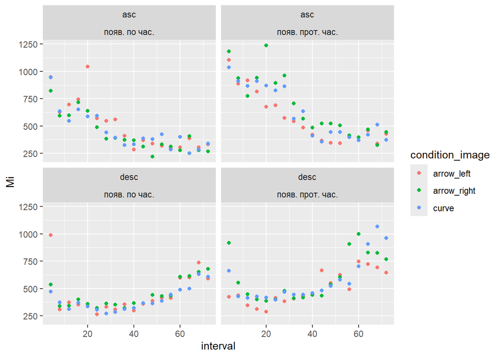

```r
graph_dt %>%
  group_by(order, interval, condition_direction, condition_image) %>%
  summarise(Mi = median(duration)) %>%
  ggplot(aes(y = Mi, x = interval, color = condition_image))+
  geom_point()+
  facet_wrap(~ order + condition_direction)
```

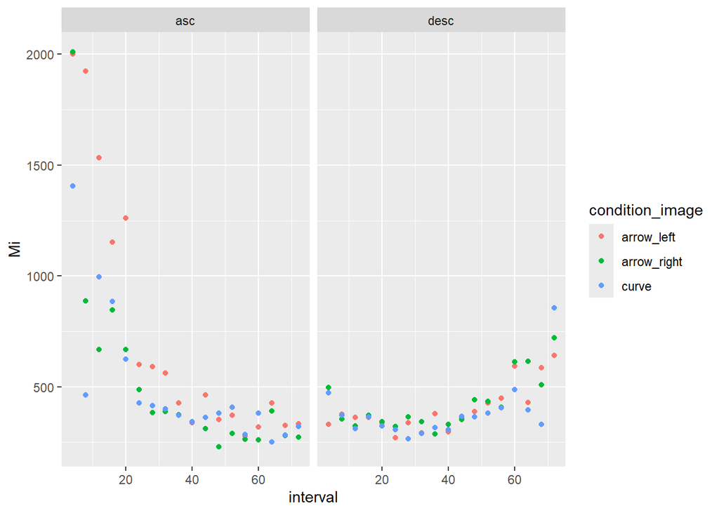

```r
graph_dt %>%
  filter(condition_direction == 'появ. по час.' &
         response == 'каж по. час.') %>%
  group_by(order, interval, condition_image) %>%
  summarise(Mi = median(duration)) %>%
  ggplot(aes(y = Mi, x = interval, color = condition_image))+
  geom_point()+
  facet_wrap(~ order)
```

Если смотреть график только там, где человек субъективно отметил, что видит движение - разброс становится больше (потому-что на коротких интервалах мало человек, которые отвечали, что видят движения), при этом рисунок вырисовывается более чётко между тремя условиями.

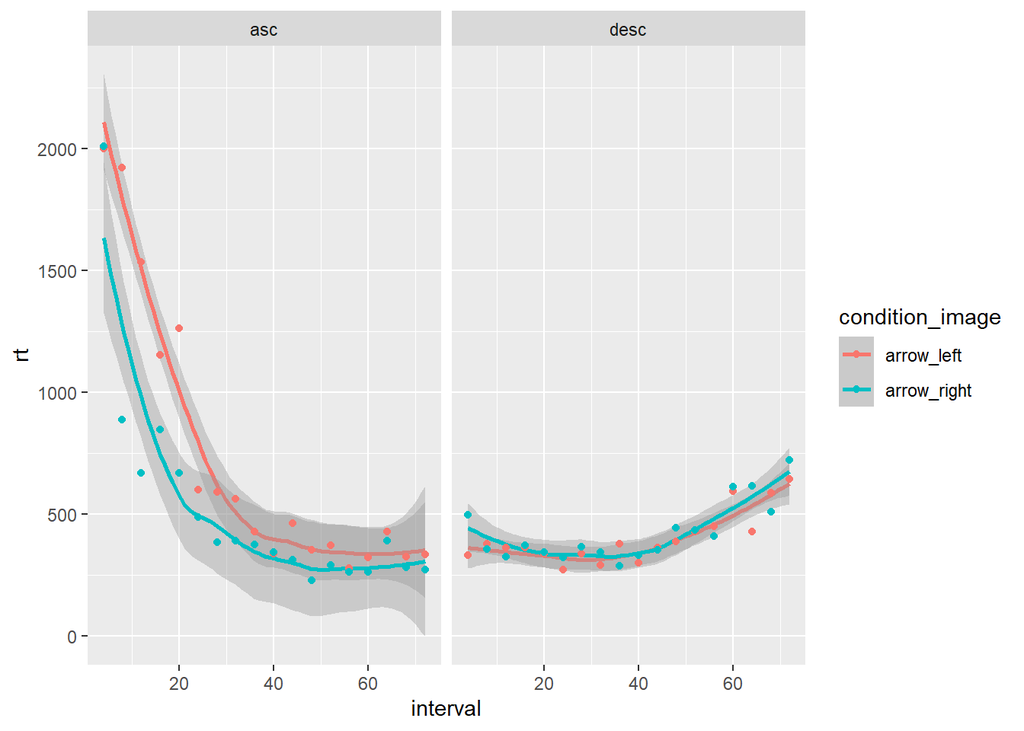

```r
graph_dt %>%
  filter(condition_direction == 'появ. по час.' &
         response == 'каж по. час.' &
         condition_image != 'curve') %>%
  group_by(interval, order, condition_image) %>%
  summarise(rt = median(duration)) %>%
  ggplot(aes(y = rt, x = interval, color = condition_image))+
  geom_smooth(method = "loess", se = TRUE, level = 0.95) +  # 95% CI
  geom_point()+
  facet_wrap(~ order)
```

```r
ggsave("график времени ответов вместе с доверительными интервалами  (left vs right).png")
```

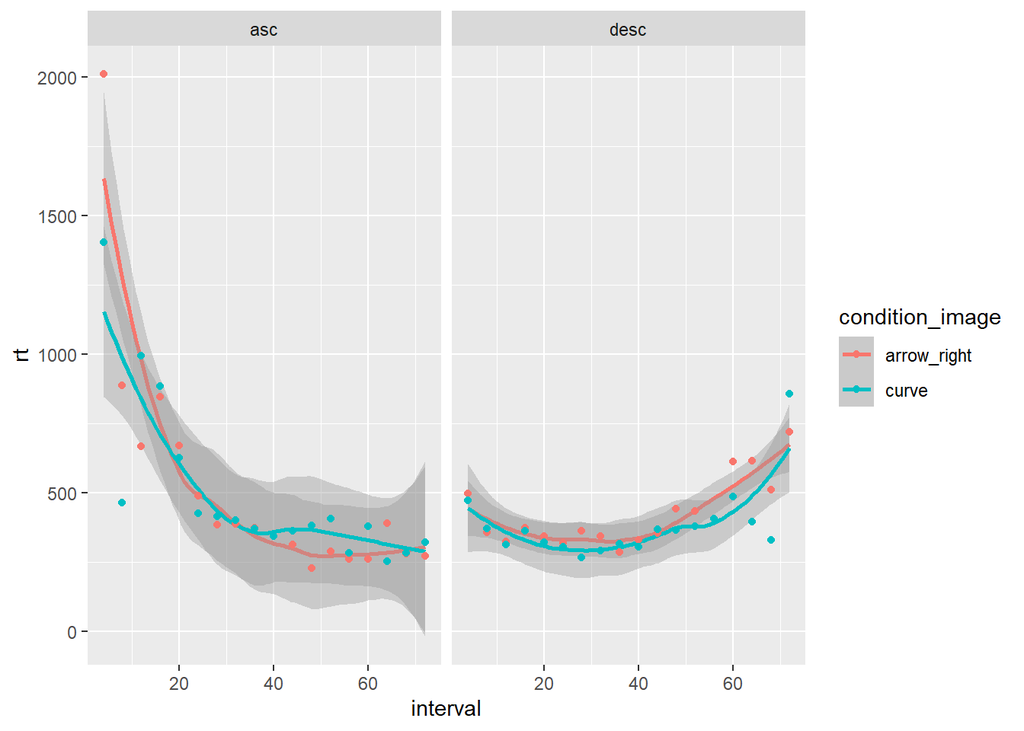

```r
graph_dt %>%
  filter(condition_direction == 'появ. по час.' &
         response == 'каж по. час.' &
         condition_image != 'arrow_left') %>%
  group_by(interval, order, condition_image) %>%
  summarise(rt = median(duration)) %>%
  ggplot(aes(y = rt, x = interval, color = condition_image))+
  geom_smooth(method = "loess", se = TRUE, level = 0.95) +  # 95% CI
  geom_point()+
  facet_wrap(~ order)
```

```r
ggsave("график времени ответов вместе с доверительными интервалами  (curve vs right).png")
```

Видно также, как и в случае с ответами, что различаются в основном arrow_right и arrow_left, а arrow_right и curve - нет

### График для движений против часовой

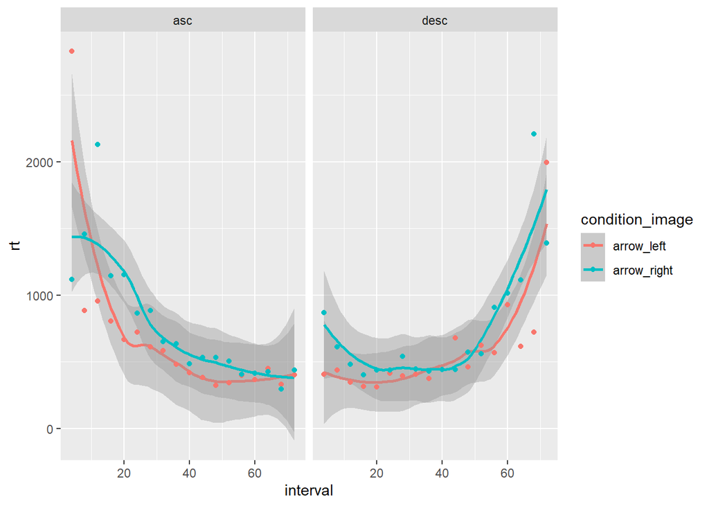

```r
graph_dt %>%
  filter(condition_direction != 'появ. по час.' &
         response == 'каж. прот. час.' &
         condition_image != 'curve') %>%
  group_by(interval, order, condition_image) %>%
  summarise(rt = median(duration)) %>%
  ggplot(aes(y = rt, x = interval, color = condition_image))+
  geom_smooth(method = "loess", se = TRUE, level = 0.95) +  # 95% CI
  geom_point()+
  facet_wrap(~ order)
```

```r
ggsave("график времени ответов вместе с доверительными интервалами - против (left vs right).png")
```

### Сравнение по критериям

```r
w_test <- function(i) {
  dt %>%
    filter(condition_direction == 'clockwise' &
           order == 'asc' &
           interval == i) %>%
    rstatix::wilcox_test(duration ~ condition_image, paired = TRUE) %>%
    print()
}
```

```r
w_test(4)
```

```
## # A tibble: 3 × 9
##   .y.      group1      group2        n1    n2 statistic     p p.adj p.adj.signif
## * <chr>    <chr>       <chr>      <int> <int>     <dbl> <dbl> <dbl> <chr>
## 1 duration arrow_left  arrow_rig…    30    30       221 0.821     1 ns
## 2 duration arrow_left  curve         30    30       212 0.681     1 ns
## 3 duration arrow_right curve         30    30       253 0.681     1 ns
```

```r
w_test(8)
```

```
## # A tibble: 3 × 9
##   .y.      group1      group2        n1    n2 statistic     p p.adj p.adj.signif
## * <chr>    <chr>       <chr>      <int> <int>     <dbl> <dbl> <dbl> <chr>
## 1 duration arrow_left  arrow_rig…    30    30       291 0.233 0.699 ns
## 2 duration arrow_left  curve         30    30       282 0.314 0.699 ns
## 3 duration arrow_right curve         30    30       216 0.742 0.742 ns
```

```r
w_test(12)
```

```
## # A tibble: 3 × 9
##   .y.      group1      group2        n1    n2 statistic     p p.adj p.adj.signif
## * <chr>    <chr>       <chr>      <int> <int>     <dbl> <dbl> <dbl> <chr>
## 1 duration arrow_left  arrow_rig…    30    30       288 0.258 0.516 ns
## 2 duration arrow_left  curve         30    30       308 0.123 0.369 ns
## 3 duration arrow_right curve         30    30       252 0.696 0.696 ns
```

```r
w_test(16)
```

```
## # A tibble: 3 × 9
##   .y.      group1      group2        n1    n2 statistic     p p.adj p.adj.signif
## * <chr>    <chr>       <chr>      <int> <int>     <dbl> <dbl> <dbl> <chr>
## 1 duration arrow_left  arrow_rig…    30    30       344 0.022 0.067 ns
## 2 duration arrow_left  curve         30    30       298 0.181 0.362 ns
## 3 duration arrow_right curve         30    30       253 0.681 0.681 ns
```

```r
w_test(20)
```

```
## # A tibble: 3 × 9
##   .y.      group1      group2        n1    n2 statistic     p p.adj p.adj.signif
## * <chr>    <chr>       <chr>      <int> <int>     <dbl> <dbl> <dbl> <chr>
## 1 duration arrow_left  arrow_rig…    30    30       344 0.022 0.064 ns
## 2 duration arrow_left  curve         30    30       345 0.021 0.064 ns
## 3 duration arrow_right curve         30    30       252 0.696 0.696 ns
```

```r
w_test(24)
```

```
## # A tibble: 3 × 9
##   .y.      group1      group2        n1    n2 statistic     p p.adj p.adj.signif
## * <chr>    <chr>       <chr>      <int> <int>     <dbl> <dbl> <dbl> <chr>
## 1 duration arrow_left  arrow_rig…    30    30       362 0.008 0.018 *
## 2 duration arrow_left  curve         30    30       227 0.918 0.918 ns
## 3 duration arrow_right curve         30    30        98 0.006 0.018 *
```

```r
w_test(28)
```

```
## # A tibble: 3 × 9
##   .y.      group1      group2        n1    n2 statistic     p p.adj p.adj.signif
## * <chr>    <chr>       <chr>      <int> <int>     <dbl> <dbl> <dbl> <chr>
## 1 duration arrow_left  arrow_rig…    30    30       361 0.008 0.025 *
## 2 duration arrow_left  curve         30    30       354 0.013 0.026 *
## 3 duration arrow_right curve         30    30       204 0.565 0.565 ns
```

```r
w_test(32)
```

```
## # A tibble: 3 × 9
##   .y.      group1      group2        n1    n2 statistic     p p.adj p.adj.signif
## * <chr>    <chr>       <chr>      <int> <int>     <dbl> <dbl> <dbl> <chr>
## 1 duration arrow_left  arrow_rig…    30    30       312 0.104 0.208 ns
## 2 duration arrow_left  curve         30    30       357 0.011 0.032 *
## 3 duration arrow_right curve         30    30       239 0.902 0.902 ns
```

```r
w_test(36)
```

```
## # A tibble: 3 × 9
##   .y.      group1      group2        n1    n2 statistic     p p.adj p.adj.signif
## * <chr>    <chr>       <chr>      <int> <int>     <dbl> <dbl> <dbl> <chr>
## 1 duration arrow_left  arrow_rig…    30    30       294 0.21  0.42  ns
## 2 duration arrow_left  curve         30    30       324 0.061 0.184 ns
## 3 duration arrow_right curve         30    30       291 0.233 0.42  ns
```

```r
w_test(40)
```

```
## # A tibble: 3 × 9
##   .y.      group1      group2        n1    n2 statistic     p p.adj p.adj.signif
## * <chr>    <chr>       <chr>      <int> <int>     <dbl> <dbl> <dbl> <chr>
## 1 duration arrow_left  arrow_rig…    30    30       309 0.118 0.354 ns
## 2 duration arrow_left  curve         30    30       275 0.388 0.776 ns
## 3 duration arrow_right curve         30    30       225 0.886 0.886 ns
```